# Must Know Pandas functions 🐼and Basics of Data Analysis 🛠

**Pandas is a fast, powerful, flexible and easy to use open source data analysis and manipulation tool,built on top of the Python programming language. Data analysis is a process of inspecting, cleansing, transforming, and modeling data with the goal of discovering useful information, forming conclusions, and supporting decision-making.**  
**Here I have tried to cover few basic functions , examples to understand, silicing, groupby, concatenate,merge tables that can be used during Data Analysis stage.**

Here are my other notebooks....Do checkout if you find my work helpful, happy learning.

1.[Predicting If Customer will borrow Personal Loan](http://www.kaggle.com/yogidsba/personal-loan-logistic-regression-decision-tree)

2.[Predict Prices of Used cars](https://www.kaggle.com/yogidsba/predict-used-car-prices-linearregression)

3.[Insurance Claim Hypothesis Testing](http://www.kaggle.com/yogidsba/insurance-claims-eda-hypothesis-testing)

4.[Basic EDA on Covid vaccination](http://www.kaggle.com/yogidsba/basic-eda-on-covid-vaccination)

5.[Case study EDA on cardio good fitness](http://www.kaggle.com/yogidsba/casestudy-eda-for-cardio-good-fitness)

# **📑Table of Contents📑**

🌐 Basic Pandas functions  
🤷‍Purpose of Analysis  
📖 Reading Dataset  
👀 Exploring Dataset  
🎭 Converting Datatypes  
🩸 Add/Rename/Drop/Filter Columns  
❓ Missing Values  
📄 Descriptive Statistics  
🔪 Slicing/Subsetting  
👨‍👨‍👯‍Data Aggregation ,Combining data frame and Groupby

⛳Purpose : The biggest motivation for this notebook was a simple thought to get better at Pandas.The best way to learn or improve is to write about it .With this thought process, I have created a simple tutorial along with a Case study on a Youtube trending Dataset to provide examples how these Panda functions can be used during analysis.  
There can be more functions,which I may not be aware of or not used .Do write in comments any basic functions which I may have missed, or if you approach a problem differently.

Source : https://pandas.pydata.org/pandas-docs/stable/?v=20210321105443  
https://en.wikipedia.org/wiki/Data_analysis  
https://github.com/jakevdp/PythonDataScienceHandbook/tree/master/notebooks

# **🌐 Basic Pandas functions 🌐**

# Basic Pandas functions

*Getting Dataset: 🧧*

| To Read Dataset From | Method |
| --- | --- |
| CSV | pd.read_csv(filename) |
| TAB/Delimited /TSV | pd.read_table(filename) |
| EXCEL | d.read_excel('myfile.xlsx',sheet_name='Sheet1', index_col=None) |
| SQL Table | pd.read_sql(query,connection_object) |
| JSON formatted string< | pd.read_json(json_string) |
| HTML url | pd.read_html(url) |
| Clipboard | pd.read_clipboard() |

*Analyzing Dataset🔭🔭 : When you begin working with a new data set, it is best to check out the first few rows ,look at datatypes, check for any datatype mismatch in variables. This will show you what kind of data is in the dataset, what data types you are working with, and help you in your analysis.*

| Description | Method |
| --- | --- |
| Displays top 5 row or n rows; | df_india.head()/df_india.head(n) |
| Displays bottom 5 row or n rows | df_india.tail()/df_india.tail(n) |
| Displays randomly selected rows | df_india.sample(n) |
| Selecting certain columns | col=['title','trending_date','view_count'] df_india[col].head() |
| Select and order top n entries | df_india.nlargest(10, 'view_count') |
| Select and order bottom n entries | df_india.nsmallest(10, 'view_count') |
| Distinct values in a column | df_india['trending_date'].nunique() |
| Count number of rows with each unique value of variable | df_india['trending_date'].value_counts() |
| To display datatypes of variables | df_india.dtypes |
| Displays numbers of rows and column our dataset contains.Its a tuple representing the dimensions | df_india.shape |
| This method print info about a dataset including the index dtype and columns,non-null values and memory usage | df_india.info() |
| A selection of numeric dtypes to be included/excluded. | df_india.select_dtypes(include = [np.number]).dtypes |
| A selection of object dtypes to be included/excluded. | df_india.select_dtypes(include = [np.object]).dtypes |
| A selection of datetime dtypes to be included/excluded. | df_india.select_dtypes(include = [np.datetime64]).dtypes |
| To select Pandas categorical dtypes | df_india.select_dtypes(include = 'category').dtypes |

*Converting Datatypes 🎭: Pandas automatically assign datatype to the columns,depending on what data the columns hold.For eg weight column may have data in form of 60.5kg so the datatype here would be object. But we want weight to be float . We can remove kg and change data type to float.*

| Description | Method |
| --- | --- |
| To convert object datatype to categorical datatype | df_india.description=df_india.description.astype("category") |
| To convert object datatype to Integer datatype | df_india.description=df_india.description.astype("int") |
| To convert object datatype to float datatype | df['DataFrame Column'] = df['DataFrame Column'].astype(float) |
| To Convert object to datetime datatype | df_india.publishedAt=pd.to_datetime(df_india.publishedAt) |
| To make a copy of dataset | df_copy=df_india.copy() |

*Adding /Renaming/Dropping Columns ➕🩸🩸*

| Description | Method |
| --- | --- |
| To add new columns to a dataframe. | df_india['count_max_view'] =df_india.groupby(['video_id'])['view_count'].transform(max) |
| To rename a column | df_india.rename(columns={'description':'desc'}) |
| To drop a column | df_india.drop() |

*Descriptive Statistics📄📄 Descriptive statistics, which include things like the mean, median,Quartiles,Minimum,Standard Deviation etc of the data , can be useful to understand the spread of the variables are and what variables may be the most important. Descriptive statistics on pandas objects exclude missing data by default*

| Description | Method |
| --- | --- |
| To get statistical summary for numeric value, to understand the distrubution | df_india.describe()(n) |
| To get summary for Categorical value | df_india.describe(include='category') |
| To get Minimum value for all numeric columns | df_india.min() |
| To get Mean value for all numeric columnss | df_india.mean() |
| To get exact middle value among a dataset. Useful for skewed distribution or data with outliers | df_india.median() |
| To get most frequent element in a dataset. | df_india.mode() |
| To get standard deviation of numeric column | df_india.std() |

*Checking and Handling Missing Values.:❓❓ .When no data value is stored for feature for a particular observation, we say this feature has a missing value.Missing value handling is a post in itself and will be covered later*

| Description | Method |
| --- | --- |
| This function returns boolean value indicating whether values are missing (NaN) | df.isna() |
| This function check for not null or non-missing values. | df.notna() |
| This function is used to replace values with other values dynamically. | df.Replace() |
| This function checks for not null or non-missing values. | pd.notnull() |
| This function is used to remove missing value. | pd.dropna() |
| Return a copy of the data with missing values filled or imputed | pd.fillna() |

*Slicing /Subsetting DataSet :🔪🔪 One of the most effective ways to get more information out of a dataset is to divide it into smaller, more uniform subsets, and analyze each of these "subset" on its own.*

| Description | Method |
| --- | --- |
| To Select rows by position use ilocs . It allows integer-location based indexing for selections . | df_india.iloc[10:4] |
| To select data based on labels, which means that we have to specify the name of the rows and columns that we need to filter out | df_india.loc[df_india['title','view_count]] |
| Query the columns of a DataFrame with a boolean expression. | df_india.query['category == 24'] |

*Data Aggregation,comibing dataframe and Groupby:👯‍♂️👯‍👨‍👨‍👦‍👦 One of the most basic analysis functions is grouping and aggregating data. An aggregation function is one which takes multiple individual values and returns a summary.In pandas, the groupby function can be combined with one or more aggregation functions to quickly and easily summarize data.*

| Description | Method |
| --- | --- |
| To find total count,unique observatoin | agg_func_count = {'view_count': ['count', 'nunique']} df_merge.groupby(['category']).agg(agg_func_count) |
| To find increased number of likes | agg_func_selection = {'likes': ['first', 'last']} df_merge.sort_values(by=['channelTitle'], ascending=False).groupby(['channelTitle' ]).agg(agg_func_selection) |
| To merge category dataset with trending dataset | df_merge = df_india.merge(df_category, on = 'categoryId', how = 'inner') |
| To concatenate Us and canada dataset | df_con_us_ca=pd.concat([df_us,df_ca]) |

# **🤷‍ Purpose of Analysis 🤷‍**

# Purpose of Analysis

*Data analysis starts with questions, not data or a some specific techniques. What is that you want to acheive with this data?What are the questions you want to answer with your data.? what kind of problems you want to address.?The questions will keep on evolving as we look at data. Finally "Analysis without question / or problems to solve is aimless."*

I am using the Youtube Trending dataset to demonstrate the functions.I will not be covering the analysis other Kaggle teammates have performed so looking for some new question in dataset for India.(since the dataset may change i will be creating a subset till 25 April 2021).

*We start with importing the pandas package along with other libraries.📚*

```python
import numpy as np
import pandas as pd
import matplotlib.pyplot as plt
%matplotlib inline
import seaborn as sns
import warnings
import json
warnings.filterwarnings('ignore') # To supress warnings
sns.set(style="darkgrid") # set the background for the graphs
pd.set_option('display.float_format', lambda x: '%.3f' % x)
```

# **📖 Reading Data 📖**

# Reading Data

*Set path for Data file and Load data* .

```python
#Reading Dataset of trends in india
path_india='../input/youtube-trending-video-dataset/IN_youtube_trending_data.csv'
df_india = pd.read_csv(path_india)
#df_inda.loc[publishedAt]
```

```python
#since the dataset may change i will be creating a subset till 25 April 2021).
df_india=df_india.loc[df_india['publishedAt'] < '2021-04-25']
```

# **👀 Exploring Dataset 👀**

# Exploring Dataset

*We start with inspecting the dataset and record observations:*  
1.Check if it is correct dataset ?.  
2.Check for attributes/columns,check if headers are clean  
3.Number of row and columns in data set (Dimension of dataset)  
4.What are the data types of your data, and how many columns are numeric?  
5.Are the datatype correct .?

```python
#This function returns the first 5 rows for the dataset
df_india.head()
```

|  | video_id | title | publishedAt | channelId | channelTitle | categoryId | trending_date | tags | view_count | likes | dislikes | comment_count | thumbnail_link | comments_disabled | ratings_disabled | description |
| --- | --- | --- | --- | --- | --- | --- | --- | --- | --- | --- | --- | --- | --- | --- | --- | --- |
| 0 | Iot0eF6EoNA | Sadak 2 \| Official Trailer \| Sanjay \| Pooja \| ... | 2020-08-12T04:31:41Z | UCGqvJPRcv7aVFun-eTsatcA | FoxStarHindi | 24 | 2020-08-12T00:00:00Z | sadak\|sadak 2\|mahesh bhatt\|vishesh films\|pooja... | 9885899 | 224925 | 3979409 | 350210 | https://i.ytimg.com/vi/Iot0eF6EoNA/default.jpg | False | False | Three Streams. Three Stories. One Journey. Sta... |
| 1 | x-KbnJ9fvJc | Kya Baat Aa : Karan Aujla (Official Video) Tan... | 2020-08-11T09:00:11Z | UCm9SZAl03Rev9sFwloCdz1g | Rehaan Records | 10 | 2020-08-12T00:00:00Z | [None] | 11308046 | 655450 | 33242 | 405146 | https://i.ytimg.com/vi/x-KbnJ9fvJc/default.jpg | False | False | Singer/Lyrics: Karan Aujla Feat Tania Music/ D... |
| 2 | KX06ksuS6Xo | Diljit Dosanjh: CLASH (Official) Music Video \|... | 2020-08-11T07:30:02Z | UCZRdNleCgW-BGUJf-bbjzQg | Diljit Dosanjh | 10 | 2020-08-12T00:00:00Z | clash diljit dosanjh\|diljit dosanjh\|diljit dos... | 9140911 | 296533 | 6179 | 30058 | https://i.ytimg.com/vi/KX06ksuS6Xo/default.jpg | False | False | CLASH official music video performed by DILJIT... |
| 3 | UsMRgnTcchY | Dil Ko Maine Di Kasam Video \| Amaal M Ft.Ariji... | 2020-08-10T05:30:49Z | UCq-Fj5jknLsUf-MWSy4_brA | T-Series | 10 | 2020-08-12T00:00:00Z | hindi songs\|2020 hindi songs\|2020 new songs\|t-... | 23564512 | 743931 | 84162 | 136942 | https://i.ytimg.com/vi/UsMRgnTcchY/default.jpg | False | False | Gulshan Kumar and T-Series presents Bhushan Ku... |
| 4 | WNSEXJJhKTU | Baarish (Official Video) Payal Dev,Stebin Ben ... | 2020-08-11T05:30:13Z | UCye6Oz0mg46S362LwARGVcA | VYRLOriginals | 10 | 2020-08-12T00:00:00Z | VYRL Original\|Mohsin Khan\|Shivangi Joshi\|Payal... | 6783649 | 268817 | 8798 | 22984 | https://i.ytimg.com/vi/WNSEXJJhKTU/default.jpg | False | False | VYRL Originals brings to you ‘Baarish’ - the b... |

```python
#displays last 5 rows
df_india.tail()
```

|  | video_id | title | publishedAt | channelId | channelTitle | categoryId | trending_date | tags | view_count | likes | dislikes | comment_count | thumbnail_link | comments_disabled | ratings_disabled | description |
| --- | --- | --- | --- | --- | --- | --- | --- | --- | --- | --- | --- | --- | --- | --- | --- | --- |
| 48274 | LfFkOD_H83Q | सलमान की दिव्य शक्ति ने लड़की को बचाया - सलमान ... | 2021-04-24T16:01:10Z | UCw6qK47Hh_Mhy1ubt4DeASw | Filmy Duniya | 24 | 2021-05-01T00:00:00Z | saawan movie salman khan scene\|saawan movie sa... | 8937218 | 65600 | 14268 | 4767 | https://i.ytimg.com/vi/LfFkOD_H83Q/default.jpg | False | False | सलमान की दिव्य शक्ति ने लड़की को बचाया - सलमान ... |
| 48297 | Z7XiKx_rj2I | Wafa Na Raas Aayee Song Jubin Nautiyal Ft.Hima... | 2021-04-23T05:31:27Z | UCq-Fj5jknLsUf-MWSy4_brA | T-Series | 10 | 2021-05-01T00:00:00Z | hindi songs\|2021 hindi songs\|new hindi songs\|2... | 64552880 | 1390809 | 42520 | 64192 | https://i.ytimg.com/vi/Z7XiKx_rj2I/default.jpg | False | False | Gulshan Kumar & T-Series presents Bhushan Kuma... |
| 48323 | 31TTJ_aFAY4 | Hot Ball and Sponge Experiment #Shorts | 2021-04-21T07:45:00Z | UCatfiM69M9ZnNhOzy0jZ41A | Power Vision | 28 | 2021-05-01T00:00:00Z | experiment\|sponge\|hot ball\|tests | 7019934 | 45798 | 7469 | 211 | https://i.ytimg.com/vi/31TTJ_aFAY4/default.jpg | False | False | #experiment #test #scienceCan a ball heated to... |
| 48443 | V6bpRSKjQME | Kabhi aise apne Doggy ko copy kia hai😂 #Shorts... | 2021-04-24T14:05:59Z | UCOxGzd-Wfd6BiP6_YXbDnLA | imkavy | 22 | 2021-05-02T00:00:00Z | [None] | 25120054 | 294763 | 31801 | 2425 | https://i.ytimg.com/vi/V6bpRSKjQME/default.jpg | False | False | NaN |
| 48475 | LfFkOD_H83Q | सलमान की दिव्य शक्ति ने लड़की को बचाया - सलमान ... | 2021-04-24T16:01:10Z | UCw6qK47Hh_Mhy1ubt4DeASw | Filmy Duniya | 24 | 2021-05-02T00:00:00Z | saawan movie salman khan scene\|saawan movie sa... | 9764555 | 70454 | 14900 | 4827 | https://i.ytimg.com/vi/LfFkOD_H83Q/default.jpg | False | False | सलमान की दिव्य शक्ति ने लड़की को बचाया - सलमान ... |

```python
print ("Rows     : " , df_india.shape[0]) #Displays numbers of rows .
print ("Columns  : " , df_india.shape[1]) # and column our dataset contains.
print ("\nFeatures : \n", df_india.columns.tolist())#displays column names
print ("\nMissing values :  ", df_india.isnull().sum().values.sum())   #find missing values
print ("\nUnique values :  \n", df_india.nunique())  # Count distinct observations
```

```
Rows     :  47632
Columns  :  16

Features :
 ['video_id', 'title', 'publishedAt', 'channelId', 'channelTitle', 'categoryId', 'trending_date', 'tags', 'view_count', 'likes', 'dislikes', 'comment_count', 'thumbnail_link', 'comments_disabled', 'ratings_disabled', 'description']

Missing values :   668

Unique values :
 video_id             13889
title                14113
publishedAt          13738
channelId             1940
channelTitle          1969
categoryId              14
trending_date          258
tags                  9769
view_count           47071
likes                39313
dislikes             12094
comment_count        16099
thumbnail_link       13890
comments_disabled        2
ratings_disabled         2
description          13243
dtype: int64
```

```python
# Displays columns and datatype .
df_india.dtypes
```

```
video_id             object
title                object
publishedAt          object
channelId            object
channelTitle         object
categoryId            int64
trending_date        object
tags                 object
view_count            int64
likes                 int64
dislikes              int64
comment_count         int64
thumbnail_link       object
comments_disabled      bool
ratings_disabled       bool
description          object
dtype: object
```

```python
#This method prints information about a dataset including the index dtype and columns,
#non-null values and memory usage.
df_india.info()
```

```
<class 'pandas.core.frame.DataFrame'>
Int64Index: 47632 entries, 0 to 48475
Data columns (total 16 columns):
 #   Column             Non-Null Count  Dtype
---  ------             --------------  -----
 0   video_id           47632 non-null  object
 1   title              47632 non-null  object
 2   publishedAt        47632 non-null  object
 3   channelId          47632 non-null  object
 4   channelTitle       47631 non-null  object
 5   categoryId         47632 non-null  int64
 6   trending_date      47632 non-null  object
 7   tags               47632 non-null  object
 8   view_count         47632 non-null  int64
 9   likes              47632 non-null  int64
 10  dislikes           47632 non-null  int64
 11  comment_count      47632 non-null  int64
 12  thumbnail_link     47632 non-null  object
 13  comments_disabled  47632 non-null  bool
 14  ratings_disabled   47632 non-null  bool
 15  description        46965 non-null  object
dtypes: bool(2), int64(5), object(9)
memory usage: 5.5+ MB
```

```python
#We can select subset of data
col=['video_id','title','trending_date','view_count']
df_india[col].head()
```

|  | video_id | title | trending_date | view_count |
| --- | --- | --- | --- | --- |
| 0 | Iot0eF6EoNA | Sadak 2 \| Official Trailer \| Sanjay \| Pooja \| ... | 2020-08-12T00:00:00Z | 9885899 |
| 1 | x-KbnJ9fvJc | Kya Baat Aa : Karan Aujla (Official Video) Tan... | 2020-08-12T00:00:00Z | 11308046 |
| 2 | KX06ksuS6Xo | Diljit Dosanjh: CLASH (Official) Music Video \|... | 2020-08-12T00:00:00Z | 9140911 |
| 3 | UsMRgnTcchY | Dil Ko Maine Di Kasam Video \| Amaal M Ft.Ariji... | 2020-08-12T00:00:00Z | 23564512 |
| 4 | WNSEXJJhKTU | Baarish (Official Video) Payal Dev,Stebin Ben ... | 2020-08-12T00:00:00Z | 6783649 |

```python
#The dataset can have many columns , this lets us select only columns with number datatype.
df_india.select_dtypes(include = [np.number]).dtypes
```

```
categoryId       int64
view_count       int64
likes            int64
dislikes         int64
comment_count    int64
dtype: object
```

```python
#This will show columns with only object datatypes
df_india.select_dtypes(include = [np.object]).dtypes
```

```
video_id          object
title             object
publishedAt       object
channelId         object
channelTitle      object
trending_date     object
tags              object
thumbnail_link    object
description       object
dtype: object
```

```python
#Display  only object datatype columns
df_india[df_india.select_dtypes([np.object]).columns]
```

|  | video_id | title | publishedAt | channelId | channelTitle | trending_date | tags | thumbnail_link | description |
| --- | --- | --- | --- | --- | --- | --- | --- | --- | --- |
| 0 | Iot0eF6EoNA | Sadak 2 \| Official Trailer \| Sanjay \| Pooja \| ... | 2020-08-12T04:31:41Z | UCGqvJPRcv7aVFun-eTsatcA | FoxStarHindi | 2020-08-12T00:00:00Z | sadak\|sadak 2\|mahesh bhatt\|vishesh films\|pooja... | https://i.ytimg.com/vi/Iot0eF6EoNA/default.jpg | Three Streams. Three Stories. One Journey. Sta... |
| 1 | x-KbnJ9fvJc | Kya Baat Aa : Karan Aujla (Official Video) Tan... | 2020-08-11T09:00:11Z | UCm9SZAl03Rev9sFwloCdz1g | Rehaan Records | 2020-08-12T00:00:00Z | [None] | https://i.ytimg.com/vi/x-KbnJ9fvJc/default.jpg | Singer/Lyrics: Karan Aujla Feat Tania Music/ D... |
| 2 | KX06ksuS6Xo | Diljit Dosanjh: CLASH (Official) Music Video \|... | 2020-08-11T07:30:02Z | UCZRdNleCgW-BGUJf-bbjzQg | Diljit Dosanjh | 2020-08-12T00:00:00Z | clash diljit dosanjh\|diljit dosanjh\|diljit dos... | https://i.ytimg.com/vi/KX06ksuS6Xo/default.jpg | CLASH official music video performed by DILJIT... |
| 3 | UsMRgnTcchY | Dil Ko Maine Di Kasam Video \| Amaal M Ft.Ariji... | 2020-08-10T05:30:49Z | UCq-Fj5jknLsUf-MWSy4_brA | T-Series | 2020-08-12T00:00:00Z | hindi songs\|2020 hindi songs\|2020 new songs\|t-... | https://i.ytimg.com/vi/UsMRgnTcchY/default.jpg | Gulshan Kumar and T-Series presents Bhushan Ku... |
| 4 | WNSEXJJhKTU | Baarish (Official Video) Payal Dev,Stebin Ben ... | 2020-08-11T05:30:13Z | UCye6Oz0mg46S362LwARGVcA | VYRLOriginals | 2020-08-12T00:00:00Z | VYRL Original\|Mohsin Khan\|Shivangi Joshi\|Payal... | https://i.ytimg.com/vi/WNSEXJJhKTU/default.jpg | VYRL Originals brings to you ‘Baarish’ - the b... |
| ... | ... | ... | ... | ... | ... | ... | ... | ... | ... |
| 48274 | LfFkOD_H83Q | सलमान की दिव्य शक्ति ने लड़की को बचाया - सलमान ... | 2021-04-24T16:01:10Z | UCw6qK47Hh_Mhy1ubt4DeASw | Filmy Duniya | 2021-05-01T00:00:00Z | saawan movie salman khan scene\|saawan movie sa... | https://i.ytimg.com/vi/LfFkOD_H83Q/default.jpg | सलमान की दिव्य शक्ति ने लड़की को बचाया - सलमान ... |
| 48297 | Z7XiKx_rj2I | Wafa Na Raas Aayee Song Jubin Nautiyal Ft.Hima... | 2021-04-23T05:31:27Z | UCq-Fj5jknLsUf-MWSy4_brA | T-Series | 2021-05-01T00:00:00Z | hindi songs\|2021 hindi songs\|new hindi songs\|2... | https://i.ytimg.com/vi/Z7XiKx_rj2I/default.jpg | Gulshan Kumar & T-Series presents Bhushan Kuma... |
| 48323 | 31TTJ_aFAY4 | Hot Ball and Sponge Experiment #Shorts | 2021-04-21T07:45:00Z | UCatfiM69M9ZnNhOzy0jZ41A | Power Vision | 2021-05-01T00:00:00Z | experiment\|sponge\|hot ball\|tests | https://i.ytimg.com/vi/31TTJ_aFAY4/default.jpg | #experiment #test #scienceCan a ball heated to... |
| 48443 | V6bpRSKjQME | Kabhi aise apne Doggy ko copy kia hai😂 #Shorts... | 2021-04-24T14:05:59Z | UCOxGzd-Wfd6BiP6_YXbDnLA | imkavy | 2021-05-02T00:00:00Z | [None] | https://i.ytimg.com/vi/V6bpRSKjQME/default.jpg | NaN |
| 48475 | LfFkOD_H83Q | सलमान की दिव्य शक्ति ने लड़की को बचाया - सलमान ... | 2021-04-24T16:01:10Z | UCw6qK47Hh_Mhy1ubt4DeASw | Filmy Duniya | 2021-05-02T00:00:00Z | saawan movie salman khan scene\|saawan movie sa... | https://i.ytimg.com/vi/LfFkOD_H83Q/default.jpg | सलमान की दिव्य शक्ति ने लड़की को बचाया - सलमान ... |

47632 rows × 9 columns

```python
df_india.channelId.value_counts()
```

```
UCvrhwpnp2DHYQ1CbXby9ypQ    733
UC55IWqFLDH1Xp7iu1_xknRA    682
UC6-F5tO8uklgE9Zy8IvbdFw    521
UCp_r6Z-Oh0YTf-ym71z5Nqg    499
UCXOgAl4w-FQero1ERbGHpXQ    448
                           ...
UC7ZwSubvHEKocHTQxeExBgA      1
UC_T2dAEa21ALn6tqU9OW4TQ      1
UCkOBXV7gw9ptGFSbZwA2pDw      1
UC3uTUlmgECBnsP777U4GPKQ      1
UCG5-fqmfU302OOyQIiGubEQ      1
Name: channelId, Length: 1940, dtype: int64
```

```python
df_india['video_id'].value_counts()
```

```
Iot0eF6EoNA    11
Qah9sSIXJqk    11
2lfETGiIDf8    10
EsXG4YET4zs    10
hGf8rOwFzvo    10
               ..
jIGcVDxKLPk     1
dratqjdZ-gY     1
O4ukxq3_ras     1
wNHP4a3mNEs     1
Dy8hkVGXQLc     1
Name: video_id, Length: 13889, dtype: int64
```

```python
#counts of rows in each categoryId in the dataset
df_india['categoryId'].value_counts()
```

```
24    19287
10     8422
22     4864
23     3935
25     2054
28     2052
17     1867
26     1846
1      1040
27      922
20      776
19      305
2       246
29       16
Name: categoryId, dtype: int64
```

```python
#Select and order top n entries
df_india.nlargest(10,'view_count') # n= 10
```

|  | video_id | title | publishedAt | channelId | channelTitle | categoryId | trending_date | tags | view_count | likes | dislikes | comment_count | thumbnail_link | comments_disabled | ratings_disabled | description |
| --- | --- | --- | --- | --- | --- | --- | --- | --- | --- | --- | --- | --- | --- | --- | --- | --- |
| 3619 | gdZLi9oWNZg | BTS (방탄소년단) 'Dynamite' Official MV | 2020-08-21T03:58:10Z | UC3IZKseVpdzPSBaWxBxundA | Big Hit Labels | 10 | 2020-08-30T00:00:00Z | BIGHIT\|빅히트\|방탄소년단\|BTS\|BANGTAN\|방탄 | 253995993 | 16115240 | 756696 | 6249727 | https://i.ytimg.com/vi/gdZLi9oWNZg/default.jpg | False | False | BTS (방탄소년단) 'Dynamite' Official MVCredits:Dire... |
| 3371 | gdZLi9oWNZg | BTS (방탄소년단) 'Dynamite' Official MV | 2020-08-21T03:58:10Z | UC3IZKseVpdzPSBaWxBxundA | Big Hit Labels | 10 | 2020-08-29T00:00:00Z | BIGHIT\|빅히트\|방탄소년단\|BTS\|BANGTAN\|방탄 | 244507902 | 15948359 | 738811 | 6188781 | https://i.ytimg.com/vi/gdZLi9oWNZg/default.jpg | False | False | BTS (방탄소년단) 'Dynamite' Official MVCredits:Dire... |
| 3122 | gdZLi9oWNZg | BTS (방탄소년단) 'Dynamite' Official MV | 2020-08-21T03:58:10Z | UC3IZKseVpdzPSBaWxBxundA | Big Hit Labels | 10 | 2020-08-28T00:00:00Z | BIGHIT\|빅히트\|방탄소년단\|BTS\|BANGTAN\|방탄 | 232649205 | 15735551 | 714196 | 6064883 | https://i.ytimg.com/vi/gdZLi9oWNZg/default.jpg | False | False | BTS (방탄소년단) 'Dynamite' Official MVCredits:Dire... |
| 2892 | gdZLi9oWNZg | BTS (방탄소년단) 'Dynamite' Official MV | 2020-08-21T03:58:10Z | UC3IZKseVpdzPSBaWxBxundA | Big Hit Labels | 10 | 2020-08-27T00:00:00Z | BIGHIT\|빅히트\|방탄소년단\|BTS\|BANGTAN\|방탄 | 219110491 | 15460834 | 674291 | 5810606 | https://i.ytimg.com/vi/gdZLi9oWNZg/default.jpg | False | False | BTS (방탄소년단) 'Dynamite' Official MVCredits:Dire... |
| 2676 | gdZLi9oWNZg | BTS (방탄소년단) 'Dynamite' Official MV | 2020-08-21T03:58:10Z | UC3IZKseVpdzPSBaWxBxundA | Big Hit Labels | 10 | 2020-08-26T00:00:00Z | BIGHIT\|빅히트\|방탄소년단\|BTS\|BANGTAN\|방탄 | 208581468 | 15246514 | 646349 | 5744361 | https://i.ytimg.com/vi/gdZLi9oWNZg/default.jpg | False | False | BTS (방탄소년단) 'Dynamite' Official MVCredits:Dire... |
| 2471 | gdZLi9oWNZg | BTS (방탄소년단) 'Dynamite' Official MV | 2020-08-21T03:58:10Z | UC3IZKseVpdzPSBaWxBxundA | Big Hit Labels | 10 | 2020-08-25T00:00:00Z | BIGHIT\|빅히트\|방탄소년단\|BTS\|BANGTAN\|방탄 | 200692965 | 14994040 | 621585 | 5623663 | https://i.ytimg.com/vi/gdZLi9oWNZg/default.jpg | False | False | BTS (방탄소년단) 'Dynamite' Official MVCredits:Dire... |
| 4735 | vRXZj0DzXIA | BLACKPINK - 'Ice Cream (with Selena Gomez)' M/V | 2020-08-28T04:00:11Z | UCOmHUn--16B90oW2L6FRR3A | BLACKPINK | 10 | 2020-09-05T00:00:00Z | YG Entertainment\|YG\|와이지\|K-pop\|BLACKPINK\|블랙핑크\|블... | 184778248 | 11795683 | 879354 | 2736021 | https://i.ytimg.com/vi/vRXZj0DzXIA/default.jpg | False | False | BLACKPINK - ‘Ice Cream (with Selena Gomez)’Com... |
| 2275 | gdZLi9oWNZg | BTS (방탄소년단) 'Dynamite' Official MV | 2020-08-21T03:58:10Z | UC3IZKseVpdzPSBaWxBxundA | Big Hit Labels | 10 | 2020-08-24T00:00:00Z | BIGHIT\|빅히트\|방탄소년단\|BTS\|BANGTAN\|방탄 | 183414472 | 14678102 | 576855 | 5748648 | https://i.ytimg.com/vi/gdZLi9oWNZg/default.jpg | False | False | BTS (방탄소년단) 'Dynamite' Official MVCredits:Dire... |
| 4498 | vRXZj0DzXIA | BLACKPINK - 'Ice Cream (with Selena Gomez)' M/V | 2020-08-28T04:00:11Z | UCOmHUn--16B90oW2L6FRR3A | BLACKPINK | 10 | 2020-09-04T00:00:00Z | YG Entertainment\|YG\|와이지\|K-pop\|BLACKPINK\|블랙핑크\|블... | 176467113 | 11645401 | 865075 | 2722455 | https://i.ytimg.com/vi/vRXZj0DzXIA/default.jpg | False | False | BLACKPINK - ‘Ice Cream (with Selena Gomez)’Com... |
| 4263 | vRXZj0DzXIA | BLACKPINK - 'Ice Cream (with Selena Gomez)' M/V | 2020-08-28T04:00:11Z | UCOmHUn--16B90oW2L6FRR3A | BLACKPINK | 10 | 2020-09-03T00:00:00Z | YG Entertainment\|YG\|와이지\|K-pop\|BLACKPINK\|블랙핑크\|블... | 167334429 | 11474607 | 848974 | 2710969 | https://i.ytimg.com/vi/vRXZj0DzXIA/default.jpg | False | False | BLACKPINK - ‘Ice Cream (with Selena Gomez)’Com... |

```python
#Select and order bottom n entries.
df_india.nsmallest(10, 'view_count')  #n=10
```

|  | video_id | title | publishedAt | channelId | channelTitle | categoryId | trending_date | tags | view_count | likes | dislikes | comment_count | thumbnail_link | comments_disabled | ratings_disabled | description |
| --- | --- | --- | --- | --- | --- | --- | --- | --- | --- | --- | --- | --- | --- | --- | --- | --- |
| 46737 | hAxqygRdM4g | Earth Day 2021 Doodle | 2021-04-21T11:00:14Z | UCdq61m8s_48EhJ5OM_MCeGw | GoogleDoodles | 1 | 2021-04-22T00:00:00Z | [None] | 0 | 0 | 0 | 0 | https://i.ytimg.com/vi/hAxqygRdM4g/default.jpg | True | True | This year’s annual Earth Day Doodle highlights... |
| 46895 | hAxqygRdM4g | Earth Day 2021 Doodle | 2021-04-21T11:00:14Z | UCdq61m8s_48EhJ5OM_MCeGw | GoogleDoodles | 1 | 2021-04-23T00:00:00Z | [None] | 0 | 0 | 0 | 0 | https://i.ytimg.com/vi/hAxqygRdM4g/default.jpg | True | True | This year’s annual Earth Day Doodle highlights... |
| 47058 | hAxqygRdM4g | Earth Day 2021 Doodle | 2021-04-21T11:00:14Z | UCdq61m8s_48EhJ5OM_MCeGw | GoogleDoodles | 1 | 2021-04-24T00:00:00Z | [None] | 0 | 0 | 0 | 0 | https://i.ytimg.com/vi/hAxqygRdM4g/default.jpg | True | True | This year’s annual Earth Day Doodle highlights... |
| 47242 | hAxqygRdM4g | Earth Day 2021 Doodle | 2021-04-21T11:00:14Z | UCdq61m8s_48EhJ5OM_MCeGw | GoogleDoodles | 1 | 2021-04-25T00:00:00Z | [None] | 0 | 0 | 0 | 0 | https://i.ytimg.com/vi/hAxqygRdM4g/default.jpg | True | True | This year’s annual Earth Day Doodle highlights... |
| 47428 | hAxqygRdM4g | Earth Day 2021 Doodle | 2021-04-21T11:00:14Z | UCdq61m8s_48EhJ5OM_MCeGw | GoogleDoodles | 1 | 2021-04-26T00:00:00Z | [None] | 0 | 0 | 0 | 0 | https://i.ytimg.com/vi/hAxqygRdM4g/default.jpg | True | True | This year’s annual Earth Day Doodle highlights... |
| 47639 | hAxqygRdM4g | Earth Day 2021 Doodle | 2021-04-21T11:00:14Z | UCdq61m8s_48EhJ5OM_MCeGw | GoogleDoodles | 1 | 2021-04-27T00:00:00Z | [None] | 0 | 0 | 0 | 0 | https://i.ytimg.com/vi/hAxqygRdM4g/default.jpg | True | True | This year’s annual Earth Day Doodle highlights... |
| 47846 | hAxqygRdM4g | Earth Day 2021 Doodle | 2021-04-21T11:00:14Z | UCdq61m8s_48EhJ5OM_MCeGw | GoogleDoodles | 1 | 2021-04-28T00:00:00Z | [None] | 0 | 0 | 0 | 0 | https://i.ytimg.com/vi/hAxqygRdM4g/default.jpg | True | True | This year’s annual Earth Day Doodle highlights... |
| 17317 | hHvXxuB2pNU | IPL 2020 \| IPL 2020 Important 40 Question \| Dr... | 2020-11-11T00:30:05Z | UCUBhUPUPO27MhfVw92P-JsQ | Study In Hindi | 27 | 2020-11-11T00:00:00Z | study in hindi\|IPL 2020 IPL 2020 Important 40 ... | 15402 | 2099 | 30 | 84 | https://i.ytimg.com/vi/hHvXxuB2pNU/default.jpg | False | False | #IPL_2020 #Mumbai_Won_2020IPL #40_MCQsIPL 2020... |
| 2760 | tNSmXwfTrAk | FDC & SDC ಪರೀಕ್ಷೆಗಳ ಕುರಿತು ಹೊರಬಂತು ಪ್ರಮುಖವಾದ ಮ... | 2020-08-25T12:06:38Z | UCb1fhIFHW4-2BSfwlMBMsOg | ಉದ್ಯೋಗ ಮಿತ್ರ | 27 | 2020-08-26T00:00:00Z | [None] | 16775 | 785 | 47 | 85 | https://i.ytimg.com/vi/tNSmXwfTrAk/default.jpg | False | False | https://t.me/udyogamitrakarnataka |
| 2548 | PixCGXgD0vc | સંઘપ્રદેશ દાનહ દમણ દિવની બોર્ડર હવે લોકો માટે ... | 2020-08-24T15:31:18Z | UCMNdby4qVm2PDSlS-5SXjcA | janmanch daman | 25 | 2020-08-25T00:00:00Z | [None] | 17351 | 453 | 22 | 18 | https://i.ytimg.com/vi/PixCGXgD0vc/default.jpg | False | False | NaN |

# **🎭 Converting datatypes 🎭**

# Converting Datatypes

*Check correct datatypes for each variables like datatime , category, int etc.*  
Currently my dataset is small but in real world scenarios dataset are big so its a good practice to Use a Categorical for efficient storage of an object-dtype column with many repeated values.  
1.Changing channel id & Channel Title from object to category datatype  
2.Changing object to datetime for variables containing date

```python
#changing published date , trending_date to datetime datatype.
df_india.publishedAt= pd.to_datetime(df_india.publishedAt)
df_india.trending_date= pd.to_datetime(df_india.trending_date)
```

```python
#Changing object datatype to category for categorical variables.
#Use a Categorical for efficient storage of an object-dtype column with many repeated values.

df_india.channelId=df_india.channelId.astype("category")
df_india.channelTitle=df_india.channelTitle.astype("category")
```

```python
# verify if the datatype  are changed
df_india.info()
```

```
<class 'pandas.core.frame.DataFrame'>
Int64Index: 47632 entries, 0 to 48475
Data columns (total 16 columns):
 #   Column             Non-Null Count  Dtype
---  ------             --------------  -----
 0   video_id           47632 non-null  object
 1   title              47632 non-null  object
 2   publishedAt        47632 non-null  datetime64[ns, UTC]
 3   channelId          47632 non-null  category
 4   channelTitle       47631 non-null  category
 5   categoryId         47632 non-null  int64
 6   trending_date      47632 non-null  datetime64[ns, UTC]
 7   tags               47632 non-null  object
 8   view_count         47632 non-null  int64
 9   likes              47632 non-null  int64
 10  dislikes           47632 non-null  int64
 11  comment_count      47632 non-null  int64
 12  thumbnail_link     47632 non-null  object
 13  comments_disabled  47632 non-null  bool
 14  ratings_disabled   47632 non-null  bool
 15  description        46965 non-null  object
dtypes: bool(2), category(2), datetime64[ns, UTC](2), int64(5), object(5)
memory usage: 5.2+ MB
```

```python
df_india.select_dtypes(include = 'category').dtypes
```

```
channelId       category
channelTitle    category
dtype: object
```

# **➕🩸Add/Rename/Drop/Filter Columns➕🩸**

# Add Rename Drop Filter Columns

```python
#To rename column names
df_india.rename(columns={'comment_count':'commentcount','thumbnail_link':'thumbnaillink'},inplace=True)
```

```python
# to drop column names
df_india.drop('ratings_disabled',inplace=True,axis=1)
```

```python
# add new column that would contain latest view_count for the particular video.
#since number of views keep on increasing everyday , we will be using only single observation against a video id.
df_india['count_max_view'] =df_india.groupby(['video_id'])['view_count'].transform(max)
```

```python
#Adding column for year to the dataframe
df_india['Year']=df_india['publishedAt'].dt.year
df_india['Month']=df_india.publishedAt.dt.month
```

```python
#select columns whose name matches regular expression
df_india.filter(regex='chan')
```

|  | channelId | channelTitle |
| --- | --- | --- |
| 0 | UCGqvJPRcv7aVFun-eTsatcA | FoxStarHindi |
| 1 | UCm9SZAl03Rev9sFwloCdz1g | Rehaan Records |
| 2 | UCZRdNleCgW-BGUJf-bbjzQg | Diljit Dosanjh |
| 3 | UCq-Fj5jknLsUf-MWSy4_brA | T-Series |
| 4 | UCye6Oz0mg46S362LwARGVcA | VYRLOriginals |
| ... | ... | ... |
| 48274 | UCw6qK47Hh_Mhy1ubt4DeASw | Filmy Duniya |
| 48297 | UCq-Fj5jknLsUf-MWSy4_brA | T-Series |
| 48323 | UCatfiM69M9ZnNhOzy0jZ41A | Power Vision |
| 48443 | UCOxGzd-Wfd6BiP6_YXbDnLA | imkavy |
| 48475 | UCw6qK47Hh_Mhy1ubt4DeASw | Filmy Duniya |

47632 rows × 2 columns

```python
df_india.info()
```

```
<class 'pandas.core.frame.DataFrame'>
Int64Index: 47632 entries, 0 to 48475
Data columns (total 18 columns):
 #   Column             Non-Null Count  Dtype
---  ------             --------------  -----
 0   video_id           47632 non-null  object
 1   title              47632 non-null  object
 2   publishedAt        47632 non-null  datetime64[ns, UTC]
 3   channelId          47632 non-null  category
 4   channelTitle       47631 non-null  category
 5   categoryId         47632 non-null  int64
 6   trending_date      47632 non-null  datetime64[ns, UTC]
 7   tags               47632 non-null  object
 8   view_count         47632 non-null  int64
 9   likes              47632 non-null  int64
 10  dislikes           47632 non-null  int64
 11  commentcount       47632 non-null  int64
 12  thumbnaillink      47632 non-null  object
 13  comments_disabled  47632 non-null  bool
 14  description        46965 non-null  object
 15  count_max_view     47632 non-null  int64
 16  Year               47632 non-null  int64
 17  Month              47632 non-null  int64
dtypes: bool(1), category(2), datetime64[ns, UTC](2), int64(8), object(5)
memory usage: 6.2+ MB
```

```python
df_india.sample(3)
```

|  | video_id | title | publishedAt | channelId | channelTitle | categoryId | trending_date | tags | view_count | likes | dislikes | commentcount | thumbnaillink | comments_disabled | description | count_max_view | Year | Month |
| --- | --- | --- | --- | --- | --- | --- | --- | --- | --- | --- | --- | --- | --- | --- | --- | --- | --- | --- |
| 14716 | JXIUKeeJfZc | Chennaiku Pudhusu \| Tamil Web Series \| EP 02 \|... | 2020-10-22 09:00:53+00:00 | UCPsy4hWCtQNyrr2Q3fsq3jQ | JFW - Just for Women | 24 | 2020-10-27 00:00:00+00:00 | chennai ku pudhusu\|chennai\|comedy\|tamil\|rj sar... | 402462 | 20908 | 323 | 1103 | https://i.ytimg.com/vi/JXIUKeeJfZc/default.jpg | False | Chennaiku Pudhusu episodes will be aired every... | 402462 | 2020 | 10 |
| 44533 | qaA28VO9yH4 | 8 Year Old Loses His Mind! 🤣😱 | 2021-04-06 16:23:36+00:00 | UCDgNRuWdouD-dXgrM3fF41Q | Woody & Kleiny Extra | 22 | 2021-04-10 00:00:00+00:00 | shorts\|viral\|comedy\|best friends\|best of woody... | 22341897 | 1092251 | 27989 | 2612 | https://i.ytimg.com/vi/qaA28VO9yH4/default.jpg | False | FALLEN THROUGH THE CEILING PRANK!!This is why ... | 98126454 | 2021 | 4 |
| 14405 | 6ZkkwHXsG6Q | Lie Detector Machine - सभी झूठ पकड़े जायेंगे औ... | 2020-10-22 12:04:20+00:00 | UCSiDGb0MnHFGjs4E2WKvShw | MR. INDIAN HACKER | 28 | 2020-10-26 00:00:00+00:00 | lie detector machine\|polygraph\|mr. indian hack... | 2627774 | 264974 | 10960 | 17772 | https://i.ytimg.com/vi/6ZkkwHXsG6Q/default.jpg | False | Today We Are Going To Unbox And Test The Lie D... | 2802710 | 2020 | 10 |

# **❓Checking missing values❓**

# Missing Values

*Other than usual missing value , data can have missing value like n.a or N/A or ---etc . Need to write separate code to identity such cases.Missing Valve and handling of missing values is a big post in itself and will cover it later.*

```python
df_india.isna().sum()
```

```
video_id               0
title                  0
publishedAt            0
channelId              0
channelTitle           1
categoryId             0
trending_date          0
tags                   0
view_count             0
likes                  0
dislikes               0
commentcount           0
thumbnaillink          0
comments_disabled      0
description          667
count_max_view         0
Year                   0
Month                  0
dtype: int64
```

```python
# There are many ways to fill the missing data. For example filling the NAs with the most frequent value,
df_india.description.fillna('No description provided',inplace=True)
df_india.dropna(axis=0,inplace=True)
```

```python
df_india.isna().sum()
```

```
video_id             0
title                0
publishedAt          0
channelId            0
channelTitle         0
categoryId           0
trending_date        0
tags                 0
view_count           0
likes                0
dislikes             0
commentcount         0
thumbnaillink        0
comments_disabled    0
description          0
count_max_view       0
Year                 0
Month                0
dtype: int64
```

# **🔪 Filtering and Slicing Data 🔪**

# Slicing Subsetting

```python
#to display olny 4 rows
df_india.iloc[1:5]
```

|  | video_id | title | publishedAt | channelId | channelTitle | categoryId | trending_date | tags | view_count | likes | dislikes | commentcount | thumbnaillink | comments_disabled | description | count_max_view | Year | Month |
| --- | --- | --- | --- | --- | --- | --- | --- | --- | --- | --- | --- | --- | --- | --- | --- | --- | --- | --- |
| 1 | x-KbnJ9fvJc | Kya Baat Aa : Karan Aujla (Official Video) Tan... | 2020-08-11 09:00:11+00:00 | UCm9SZAl03Rev9sFwloCdz1g | Rehaan Records | 10 | 2020-08-12 00:00:00+00:00 | [None] | 11308046 | 655450 | 33242 | 405146 | https://i.ytimg.com/vi/x-KbnJ9fvJc/default.jpg | False | Singer/Lyrics: Karan Aujla Feat Tania Music/ D... | 37585253 | 2020 | 8 |
| 2 | KX06ksuS6Xo | Diljit Dosanjh: CLASH (Official) Music Video \|... | 2020-08-11 07:30:02+00:00 | UCZRdNleCgW-BGUJf-bbjzQg | Diljit Dosanjh | 10 | 2020-08-12 00:00:00+00:00 | clash diljit dosanjh\|diljit dosanjh\|diljit dos... | 9140911 | 296533 | 6179 | 30058 | https://i.ytimg.com/vi/KX06ksuS6Xo/default.jpg | False | CLASH official music video performed by DILJIT... | 20409549 | 2020 | 8 |
| 3 | UsMRgnTcchY | Dil Ko Maine Di Kasam Video \| Amaal M Ft.Ariji... | 2020-08-10 05:30:49+00:00 | UCq-Fj5jknLsUf-MWSy4_brA | T-Series | 10 | 2020-08-12 00:00:00+00:00 | hindi songs\|2020 hindi songs\|2020 new songs\|t-... | 23564512 | 743931 | 84162 | 136942 | https://i.ytimg.com/vi/UsMRgnTcchY/default.jpg | False | Gulshan Kumar and T-Series presents Bhushan Ku... | 33441086 | 2020 | 8 |
| 4 | WNSEXJJhKTU | Baarish (Official Video) Payal Dev,Stebin Ben ... | 2020-08-11 05:30:13+00:00 | UCye6Oz0mg46S362LwARGVcA | VYRLOriginals | 10 | 2020-08-12 00:00:00+00:00 | VYRL Original\|Mohsin Khan\|Shivangi Joshi\|Payal... | 6783649 | 268817 | 8798 | 22984 | https://i.ytimg.com/vi/WNSEXJJhKTU/default.jpg | False | VYRL Originals brings to you ‘Baarish’ - the b... | 22585040 | 2020 | 8 |

```python
#filter out dataset with a condition
df_india.loc[(df_india.channelTitle=='T-Series') & (df_india.Year == 2020),'Year'].count()
```

```
192
```

```python
# to view columns form channel id to view count
df_india.loc[:,'channelId':'view_count']
#number.sort_values(ascending = False)
```

|  | channelId | channelTitle | categoryId | trending_date | tags | view_count |
| --- | --- | --- | --- | --- | --- | --- |
| 0 | UCGqvJPRcv7aVFun-eTsatcA | FoxStarHindi | 24 | 2020-08-12 00:00:00+00:00 | sadak\|sadak 2\|mahesh bhatt\|vishesh films\|pooja... | 9885899 |
| 1 | UCm9SZAl03Rev9sFwloCdz1g | Rehaan Records | 10 | 2020-08-12 00:00:00+00:00 | [None] | 11308046 |
| 2 | UCZRdNleCgW-BGUJf-bbjzQg | Diljit Dosanjh | 10 | 2020-08-12 00:00:00+00:00 | clash diljit dosanjh\|diljit dosanjh\|diljit dos... | 9140911 |
| 3 | UCq-Fj5jknLsUf-MWSy4_brA | T-Series | 10 | 2020-08-12 00:00:00+00:00 | hindi songs\|2020 hindi songs\|2020 new songs\|t-... | 23564512 |
| 4 | UCye6Oz0mg46S362LwARGVcA | VYRLOriginals | 10 | 2020-08-12 00:00:00+00:00 | VYRL Original\|Mohsin Khan\|Shivangi Joshi\|Payal... | 6783649 |
| ... | ... | ... | ... | ... | ... | ... |
| 48274 | UCw6qK47Hh_Mhy1ubt4DeASw | Filmy Duniya | 24 | 2021-05-01 00:00:00+00:00 | saawan movie salman khan scene\|saawan movie sa... | 8937218 |
| 48297 | UCq-Fj5jknLsUf-MWSy4_brA | T-Series | 10 | 2021-05-01 00:00:00+00:00 | hindi songs\|2021 hindi songs\|new hindi songs\|2... | 64552880 |
| 48323 | UCatfiM69M9ZnNhOzy0jZ41A | Power Vision | 28 | 2021-05-01 00:00:00+00:00 | experiment\|sponge\|hot ball\|tests | 7019934 |
| 48443 | UCOxGzd-Wfd6BiP6_YXbDnLA | imkavy | 22 | 2021-05-02 00:00:00+00:00 | [None] | 25120054 |
| 48475 | UCw6qK47Hh_Mhy1ubt4DeASw | Filmy Duniya | 24 | 2021-05-02 00:00:00+00:00 | saawan movie salman khan scene\|saawan movie sa... | 9764555 |

47631 rows × 6 columns

```python
df_india.loc[:,'categoryId'].value_counts()
```

```
24    19287
10     8422
22     4863
23     3935
25     2054
28     2052
17     1867
26     1846
1      1040
27      922
20      776
19      305
2       246
29       16
Name: categoryId, dtype: int64
```

```python
#to view all records for channeltitle='Foxstarhindi'
df_india.query('channelTitle=="FoxStarHindi"')
```

|  | video_id | title | publishedAt | channelId | channelTitle | categoryId | trending_date | tags | view_count | likes | dislikes | commentcount | thumbnaillink | comments_disabled | description | count_max_view | Year | Month |
| --- | --- | --- | --- | --- | --- | --- | --- | --- | --- | --- | --- | --- | --- | --- | --- | --- | --- | --- |
| 0 | Iot0eF6EoNA | Sadak 2 \| Official Trailer \| Sanjay \| Pooja \| ... | 2020-08-12 04:31:41+00:00 | UCGqvJPRcv7aVFun-eTsatcA | FoxStarHindi | 24 | 2020-08-12 00:00:00+00:00 | sadak\|sadak 2\|mahesh bhatt\|vishesh films\|pooja... | 9885899 | 224925 | 3979409 | 350210 | https://i.ytimg.com/vi/Iot0eF6EoNA/default.jpg | False | Three Streams. Three Stories. One Journey. Sta... | 66344227 | 2020 | 8 |
| 171 | Iot0eF6EoNA | Sadak 2 \| Official Trailer \| Sanjay \| Pooja \| ... | 2020-08-12 04:31:41+00:00 | UCGqvJPRcv7aVFun-eTsatcA | FoxStarHindi | 24 | 2020-08-13 00:00:00+00:00 | sadak\|sadak 2\|mahesh bhatt\|vishesh films\|pooja... | 28165455 | 412594 | 7576610 | 659733 | https://i.ytimg.com/vi/Iot0eF6EoNA/default.jpg | False | Three Streams. Three Stories. One Journey. Sta... | 66344227 | 2020 | 8 |
| 348 | Iot0eF6EoNA | Sadak 2 \| Official Trailer \| Sanjay \| Pooja \| ... | 2020-08-12 04:31:41+00:00 | UCGqvJPRcv7aVFun-eTsatcA | FoxStarHindi | 24 | 2020-08-14 00:00:00+00:00 | sadak\|sadak 2\|mahesh bhatt\|vishesh films\|pooja... | 39577543 | 509684 | 9260973 | 818229 | https://i.ytimg.com/vi/Iot0eF6EoNA/default.jpg | False | Three Streams. Three Stories. One Journey. Sta... | 66344227 | 2020 | 8 |
| 523 | Iot0eF6EoNA | Sadak 2 \| Official Trailer \| Sanjay \| Pooja \| ... | 2020-08-12 04:31:41+00:00 | UCGqvJPRcv7aVFun-eTsatcA | FoxStarHindi | 24 | 2020-08-15 00:00:00+00:00 | sadak\|sadak 2\|mahesh bhatt\|vishesh films\|pooja... | 48458719 | 569806 | 10479328 | 926675 | https://i.ytimg.com/vi/Iot0eF6EoNA/default.jpg | False | Three Streams. Three Stories. One Journey. Sta... | 66344227 | 2020 | 8 |
| 697 | Iot0eF6EoNA | Sadak 2 \| Official Trailer \| Sanjay \| Pooja \| ... | 2020-08-12 04:31:41+00:00 | UCGqvJPRcv7aVFun-eTsatcA | FoxStarHindi | 24 | 2020-08-16 00:00:00+00:00 | sadak\|sadak 2\|mahesh bhatt\|vishesh films\|pooja... | 53865934 | 605119 | 11213118 | 981278 | https://i.ytimg.com/vi/Iot0eF6EoNA/default.jpg | False | Three Streams. Three Stories. One Journey. Sta... | 66344227 | 2020 | 8 |
| 894 | Iot0eF6EoNA | Sadak 2 \| Official Trailer \| Sanjay \| Pooja \| ... | 2020-08-12 04:31:41+00:00 | UCGqvJPRcv7aVFun-eTsatcA | FoxStarHindi | 24 | 2020-08-17 00:00:00+00:00 | sadak\|sadak 2\|mahesh bhatt\|vishesh films\|pooja... | 57978838 | 629440 | 11318674 | 1015427 | https://i.ytimg.com/vi/Iot0eF6EoNA/default.jpg | False | Three Streams. Three Stories. One Journey. Sta... | 66344227 | 2020 | 8 |
| 1099 | Iot0eF6EoNA | Sadak 2 \| Official Trailer \| Sanjay \| Pooja \| ... | 2020-08-12 04:31:41+00:00 | UCGqvJPRcv7aVFun-eTsatcA | FoxStarHindi | 24 | 2020-08-18 00:00:00+00:00 | sadak\|sadak 2\|mahesh bhatt\|vishesh films\|pooja... | 60684140 | 645367 | 11610617 | 1033525 | https://i.ytimg.com/vi/Iot0eF6EoNA/default.jpg | False | Three Streams. Three Stories. One Journey. Sta... | 66344227 | 2020 | 8 |
| 1313 | Iot0eF6EoNA | Sadak 2 \| Official Trailer \| Sanjay \| Pooja \| ... | 2020-08-12 04:31:41+00:00 | UCGqvJPRcv7aVFun-eTsatcA | FoxStarHindi | 24 | 2020-08-19 00:00:00+00:00 | sadak\|sadak 2\|mahesh bhatt\|vishesh films\|pooja... | 62560202 | 657374 | 11828671 | 1043781 | https://i.ytimg.com/vi/Iot0eF6EoNA/default.jpg | False | Three Streams. Three Stories. One Journey. Sta... | 66344227 | 2020 | 8 |
| 1548 | Iot0eF6EoNA | Sadak 2 \| Official Trailer \| Sanjay \| Pooja \| ... | 2020-08-12 04:31:41+00:00 | UCGqvJPRcv7aVFun-eTsatcA | FoxStarHindi | 24 | 2020-08-20 00:00:00+00:00 | sadak\|sadak 2\|mahesh bhatt\|vishesh films\|pooja... | 64126227 | 667503 | 12066691 | 1057203 | https://i.ytimg.com/vi/Iot0eF6EoNA/default.jpg | False | Three Streams. Three Stories. One Journey. Sta... | 66344227 | 2020 | 8 |
| 1809 | Iot0eF6EoNA | Sadak 2 \| Official Trailer \| Sanjay \| Pooja \| ... | 2020-08-12 04:31:41+00:00 | UCGqvJPRcv7aVFun-eTsatcA | FoxStarHindi | 24 | 2020-08-21 00:00:00+00:00 | sadak\|sadak 2\|mahesh bhatt\|vishesh films\|pooja... | 65454611 | 675091 | 12237370 | 1070532 | https://i.ytimg.com/vi/Iot0eF6EoNA/default.jpg | False | Three Streams. Three Stories. One Journey. Sta... | 66344227 | 2020 | 8 |
| 2070 | Iot0eF6EoNA | Sadak 2 \| Official Trailer \| Sanjay \| Pooja \| ... | 2020-08-12 04:31:41+00:00 | UCGqvJPRcv7aVFun-eTsatcA | FoxStarHindi | 24 | 2020-08-22 00:00:00+00:00 | sadak\|sadak 2\|mahesh bhatt\|vishesh films\|pooja... | 66344227 | 680408 | 12341474 | 1080479 | https://i.ytimg.com/vi/Iot0eF6EoNA/default.jpg | False | Three Streams. Three Stories. One Journey. Sta... | 66344227 | 2020 | 8 |
| 6925 | QPFP58rY-5w | Laxmmi Bomb \| Motion Poster \| Akshay Kumar \| K... | 2020-09-16 09:59:37+00:00 | UCGqvJPRcv7aVFun-eTsatcA | FoxStarHindi | 24 | 2020-09-17 00:00:00+00:00 | Laxmmi Bomb motion poster\|laxmmi bomb motion p... | 543362 | 52748 | 17743 | 7579 | https://i.ytimg.com/vi/QPFP58rY-5w/default.jpg | False | Iss Diwali aap sabke gharon mein laxmmi hi lax... | 2023881 | 2020 | 9 |
| 7122 | QPFP58rY-5w | Laxmmi Bomb \| Motion Poster \| Akshay Kumar \| K... | 2020-09-16 09:59:37+00:00 | UCGqvJPRcv7aVFun-eTsatcA | FoxStarHindi | 24 | 2020-09-18 00:00:00+00:00 | Laxmmi Bomb motion poster\|laxmmi bomb motion p... | 1136425 | 80859 | 32350 | 11556 | https://i.ytimg.com/vi/QPFP58rY-5w/default.jpg | False | Iss Diwali aap sabke gharon mein laxmmi hi lax... | 2023881 | 2020 | 9 |
| 7331 | QPFP58rY-5w | Laxmmi Bomb \| Motion Poster \| Akshay Kumar \| K... | 2020-09-16 09:59:37+00:00 | UCGqvJPRcv7aVFun-eTsatcA | FoxStarHindi | 24 | 2020-09-19 00:00:00+00:00 | Laxmmi Bomb motion poster\|laxmmi bomb motion p... | 1470824 | 94439 | 39689 | 13258 | https://i.ytimg.com/vi/QPFP58rY-5w/default.jpg | False | Iss Diwali aap sabke gharon mein laxmmi hi lax... | 2023881 | 2020 | 9 |
| 7544 | QPFP58rY-5w | Laxmmi Bomb \| Motion Poster \| Akshay Kumar \| K... | 2020-09-16 09:59:37+00:00 | UCGqvJPRcv7aVFun-eTsatcA | FoxStarHindi | 24 | 2020-09-20 00:00:00+00:00 | Laxmmi Bomb motion poster\|laxmmi bomb motion p... | 1716580 | 102413 | 44264 | 14385 | https://i.ytimg.com/vi/QPFP58rY-5w/default.jpg | False | Iss Diwali aap sabke gharon mein laxmmi hi lax... | 2023881 | 2020 | 9 |
| 7782 | QPFP58rY-5w | Laxmmi Bomb \| Motion Poster \| Akshay Kumar \| K... | 2020-09-16 09:59:37+00:00 | UCGqvJPRcv7aVFun-eTsatcA | FoxStarHindi | 24 | 2020-09-21 00:00:00+00:00 | Laxmmi Bomb motion poster\|laxmmi bomb motion p... | 1907587 | 116161 | 51844 | 15529 | https://i.ytimg.com/vi/QPFP58rY-5w/default.jpg | False | Iss Diwali aap sabke gharon mein laxmmi hi lax... | 2023881 | 2020 | 9 |
| 8030 | QPFP58rY-5w | Laxmmi Bomb \| Motion Poster \| Akshay Kumar \| K... | 2020-09-16 09:59:37+00:00 | UCGqvJPRcv7aVFun-eTsatcA | FoxStarHindi | 24 | 2020-09-22 00:00:00+00:00 | Laxmmi Bomb motion poster\|laxmmi bomb motion p... | 2023881 | 123120 | 55680 | 16342 | https://i.ytimg.com/vi/QPFP58rY-5w/default.jpg | False | Iss Diwali aap sabke gharon mein laxmmi hi lax... | 2023881 | 2020 | 9 |

# **📄 Descriptive Statistics 📄**

# Descriptive Statistics

```python
#displays only numeric variables
df_india.describe()
```

|  | categoryId | view_count | likes | dislikes | commentcount | count_max_view | Year | Month |
| --- | --- | --- | --- | --- | --- | --- | --- | --- |
| count | 47631.000 | 47631.000 | 47631.000 | 47631.000 | 47631.000 | 47631.000 | 47631.000 | 47631.000 |
| mean | 20.603 | 2706622.314 | 133096.060 | 7909.871 | 14445.980 | 3477273.557 | 2020.443 | 6.682 |
| std | 6.409 | 7060686.791 | 445910.946 | 164860.149 | 121011.297 | 8963179.875 | 0.497 | 3.995 |
| min | 1.000 | 0.000 | 0.000 | 0.000 | 0.000 | 0.000 | 2020.000 | 1.000 |
| 25% | 20.000 | 406318.000 | 13858.500 | 526.000 | 706.000 | 507825.000 | 2020.000 | 3.000 |
| 50% | 24.000 | 952418.000 | 37323.000 | 1382.000 | 2133.000 | 1152995.000 | 2020.000 | 8.000 |
| 75% | 24.000 | 2344516.000 | 101808.500 | 3771.000 | 6722.000 | 2932828.000 | 2021.000 | 10.000 |
| max | 29.000 | 253995993.000 | 16115240.000 | 12341474.000 | 6249727.000 | 253995993.000 | 2021.000 | 12.000 |

```python
# displays all varaibles
df_india.describe(exclude='number')
```

|  | video_id | title | publishedAt | channelId | channelTitle | trending_date | tags | thumbnaillink | comments_disabled | description |
| --- | --- | --- | --- | --- | --- | --- | --- | --- | --- | --- |
| count | 47631 | 47631 | 47631 | 47631 | 47631 | 47631 | 47631 | 47631 | 47631 | 47631 |
| unique | 13889 | 14113 | 13738 | 1940 | 1969 | 258 | 9769 | 13890 | 2 | 13244 |
| top | Qah9sSIXJqk | Kundali Bhagya \| कुंडली भाग्य \| Monday - Frida... | 2020-11-04 12:30:09+00:00 | UCvrhwpnp2DHYQ1CbXby9ypQ | Vijay Television | 2021-03-02 00:00:00+00:00 | [None] | https://i.ytimg.com/vi/Qah9sSIXJqk/default.jpg | False | No description provided |
| freq | 11 | 37 | 17 | 733 | 733 | 398 | 5056 | 11 | 47163 | 667 |
| first | NaN | NaN | 2020-07-23 11:30:37+00:00 | NaN | NaN | 2020-08-12 00:00:00+00:00 | NaN | NaN | NaN | NaN |
| last | NaN | NaN | 2021-04-24 17:33:20+00:00 | NaN | NaN | 2021-05-02 00:00:00+00:00 | NaN | NaN | NaN | NaN |

```python
df_india.publishedAt.min()
```

```
Timestamp('2020-07-23 11:30:37+0000', tz='UTC')
```

```python
df_india.publishedAt.max()
```

```
Timestamp('2021-04-24 17:33:20+0000', tz='UTC')
```

# **👨‍👨‍👦‍👦 Data Aggregation,Combining dataframe and Groupby👨‍👨‍👦‍👦**

# Data Aggregation,Combining dataframe and Groupby

```python
# gives us various count of video in each channel category
df_india.groupby("channelTitle").size().reset_index(name="video_count") \
    .sort_values("video_count", ascending=False).head(20)
```

|  | channelTitle | video_count |
| --- | --- | --- |
| 1796 | Vijay Television | 733 |
| 329 | Colors TV | 682 |
| 171 | Asianet | 499 |
| 1873 | ZEE5 | 448 |
| 342 | Crazy XYZ | 411 |
| 506 | Flowers Comedy | 355 |
| 1479 | Sony SAB | 353 |
| 1562 | T-Series | 344 |
| 1602 | Taarak Mehta Ka Ooltah Chashmah | 318 |
| 1505 | Star Maa | 296 |
| 1540 | Sun TV | 274 |
| 855 | MR. INDIAN HACKER | 262 |
| 637 | Hungry Birds | 191 |
| 1629 | Technical Guruji | 181 |
| 1615 | Tarang TV | 181 |
| 1382 | Saregama TV Shows Tamil | 177 |
| 1318 | SET India | 170 |
| 1896 | Zee TV | 169 |
| 1314 | SAB TV | 168 |
| 1909 | cricket.com.au | 165 |

```python
#df_india.groupby('month').count_max_view
get_month=df_india.Month.value_counts(normalize=True)
```

```python
# make a new dataframe with only single observations for each id.
df_unique_video_id=df_india.loc[df_india.view_count == df_india.count_max_view]
df_unique_video_id.loc[df_unique_video_id.Year == 2021, 'title'].count()
```

```
6281
```

```python
#Getting category for the category file
#we need id and title from this file which are under items tag and snippet contain title
with open("../input/youtube-trending-video-dataset/IN_category_id.json") as f:
    categories = json.load(f)["items"]
cat_dict = {}
category=[]
for cat in categories:
    category.append([cat["id"],cat["snippet"]["title"]])
```

```python
df_category =pd.DataFrame(category,columns=['categoryId','category'])
df_category.head(20)
```

|  | categoryId | category |
| --- | --- | --- |
| 0 | 1 | Film & Animation |
| 1 | 2 | Autos & Vehicles |
| 2 | 10 | Music |
| 3 | 15 | Pets & Animals |
| 4 | 17 | Sports |
| 5 | 18 | Short Movies |
| 6 | 19 | Travel & Events |
| 7 | 20 | Gaming |
| 8 | 21 | Videoblogging |
| 9 | 22 | People & Blogs |
| 10 | 23 | Comedy |
| 11 | 24 | Entertainment |
| 12 | 25 | News & Politics |
| 13 | 26 | Howto & Style |
| 14 | 27 | Education |
| 15 | 28 | Science & Technology |
| 16 | 30 | Movies |
| 17 | 31 | Anime/Animation |
| 18 | 32 | Action/Adventure |
| 19 | 33 | Classics |

```python
df_category.categoryId=df_category.categoryId.astype('int64')
#merge df_india and df_category to get category names
df_merge = df_india.merge(df_category, on = 'categoryId', how = 'inner')
df_merge['category']
```

```
0          Entertainment
1          Entertainment
2          Entertainment
3          Entertainment
4          Entertainment
              ...
47610    Travel & Events
47611    Travel & Events
47612    Travel & Events
47613    Travel & Events
47614    Travel & Events
Name: category, Length: 47615, dtype: object
```

```python
agg_func_count = {'view_count': ['count', 'nunique', 'size']}
df_merge.groupby(['category']).agg(agg_func_count)
```

| category | view_count count | view_count nunique | view_count size |
| --- | --- | --- | --- |
| Autos & Vehicles | 246 | 246 | 246 |
| Comedy | 3935 | 3919 | 3935 |
| Education | 922 | 919 | 922 |
| Entertainment | 19287 | 19170 | 19287 |
| Film & Animation | 1040 | 1029 | 1040 |
| Gaming | 776 | 773 | 776 |
| Howto & Style | 1846 | 1841 | 1846 |
| Music | 8422 | 8384 | 8422 |
| News & Politics | 2054 | 2043 | 2054 |
| People & Blogs | 4863 | 4834 | 4863 |
| Science & Technology | 2052 | 2044 | 2052 |
| Sports | 1867 | 1862 | 1867 |
| Travel & Events | 305 | 304 | 305 |

```python
agg_func_selection = {'likes': ['first', 'last']}
df_merge.sort_values(by=['channelTitle'],
            ascending=False).groupby(['channelTitle'
                                        ]).agg(agg_func_selection)
```

| channelTitle | likes first | likes last |
| --- | --- | --- |
| #RohiL Fitness Yug | 12079.000 | 13192.000 |
| 10 Mint Records | 95887.000 | 103128.000 |
| 10TV News Telugu | 85764.000 | 80237.000 |
| 123 GO! CHALLENGE | 53418.000 | 51555.000 |
| 123 GO! Hindi | 21041.000 | 35095.000 |
| ... | ... | ... |
| जोश Talks | 113629.000 | 67541.000 |
| मराठी तडका | 1272.000 | 3763.000 |
| ਪੰਜਾਬੀ ਲੋਕ Punjabi Lok | 24703.000 | 19016.000 |
| ಉದ್ಯೋಗ ಮಿತ್ರ | 884.000 | 785.000 |
| ജോഷ് Talks | 43799.000 | 39349.000 |

1969 rows × 2 columns

```python
path_us='../input/youtube-trending-video-dataset/US_youtube_trending_data.csv'
df_us = pd.read_csv(path_us)
path_ca='../input/youtube-trending-video-dataset/CA_youtube_trending_data.csv'
df_ca = pd.read_csv(path_ca)
```

```python
df_us.shape[0]
```

```
61391
```

```python
df_ca.shape[0]
```

```
61344
```

```python
df_merge_us_ca=pd.concat([df_us,df_ca])
```

```python
df_merge_us_ca.shape[0]
```

```
122735
```

# **Which is most watched video in India.?**

```python
# find the video which has maximum view count.
df_india[df_india['view_count'].isin([df_india.view_count.max()])]
```

|  | video_id | title | publishedAt | channelId | channelTitle | categoryId | trending_date | tags | view_count | likes | dislikes | commentcount | thumbnaillink | comments_disabled | description | count_max_view | Year | Month |
| --- | --- | --- | --- | --- | --- | --- | --- | --- | --- | --- | --- | --- | --- | --- | --- | --- | --- | --- |
| 3619 | gdZLi9oWNZg | BTS (방탄소년단) 'Dynamite' Official MV | 2020-08-21 03:58:10+00:00 | UC3IZKseVpdzPSBaWxBxundA | Big Hit Labels | 10 | 2020-08-30 00:00:00+00:00 | BIGHIT\|빅히트\|방탄소년단\|BTS\|BANGTAN\|방탄 | 253995993 | 16115240 | 756696 | 6249727 | https://i.ytimg.com/vi/gdZLi9oWNZg/default.jpg | False | BTS (방탄소년단) 'Dynamite' Official MVCredits:Dire... | 253995993 | 2020 | 8 |

# **How many video where published in year 2020?**

```python
print(" Number of video's published in year 2020 is ", df_india.loc[df_india.Year==2020,'video_id'].count())
```

```
 Number of video's published in year 2020 is  26539
```

# **How many video did Channel "T-Series" publish in year 2020?**

```python
print(" Number of video's published by 'T-series'in year 2020 is ",
      df_india.loc[(df_india.channelTitle=='T-Series') & (df_india.Year == 2020),'Year'].count())
```

```
 Number of video's published by 'T-series'in year 2020 is  192
```

# **Top 30 most watched videos**

```python
# get top 30 most watched videos
top30viewed=df_india[df_india['view_count'] == df_india['count_max_view']].sort_values(by=['count_max_view'],ascending=False).head(30)
```

```python
# we just want the first string from the title and title is pipe separated
top30viewed.title=top30viewed.title.str.split(pat='|').apply(lambda x: x[0])
```

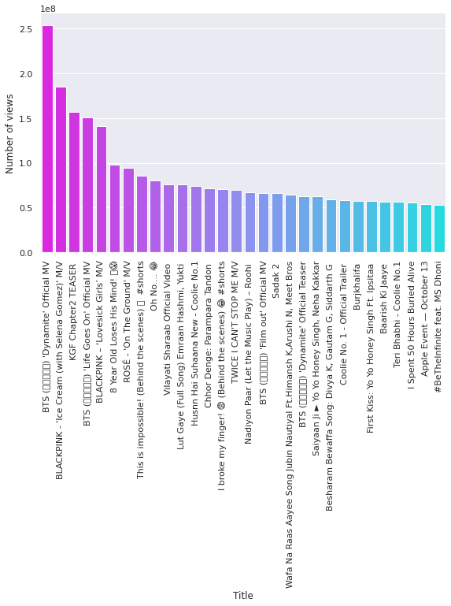

```python
#top30viewed.reset_index()
sns.catplot(data=top30viewed, x='title', y='view_count',kind='bar',palette='cool_r' ,ci=None, legend_out=False,aspect =2)

plt.ylabel('Number of views')
plt.xlabel('Title')
plt.xticks(rotation=90)
plt.show()
```

# **Top 3 Categories**

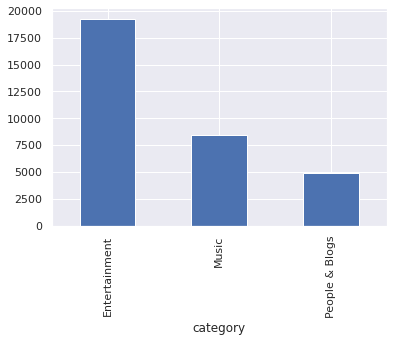

```python
df_merge.groupby(df_merge['category']).size().sort_values(ascending=False).head(3).plot(kind='bar')
```

```python
top_cat=df_merge[df_merge['categoryId']==24].sample(100)
```

```python
#to use cross tab
pd.crosstab([top_cat.channelTitle,top_cat.Year],values=top_cat['view_count'], columns=top_cat['Month'],aggfunc=len)
```

| channelTitle | Month Year | 1 | 2 | 3 | 4 | 8 | 9 | 10 | 11 | 12 |
| --- | --- | --- | --- | --- | --- | --- | --- | --- | --- | --- |
| A2 Motivation {Arvind Arora} | 2021 | NaN | 1.000 | NaN | NaN | NaN | NaN | NaN | NaN | NaN |
| ALTBalaji | 2020 | NaN | NaN | NaN | NaN | NaN | NaN | 1.000 | NaN | NaN |
|  | 2021 | 1.000 | NaN | NaN | NaN | NaN | NaN | NaN | NaN | NaN |
| ARY Digital | 2020 | NaN | NaN | NaN | NaN | NaN | NaN | 1.000 | NaN | NaN |
| Alright! | 2021 | NaN | 1.000 | NaN | NaN | NaN | NaN | NaN | NaN | NaN |
| ... | ... | ... | ... | ... | ... | ... | ... | ... | ... | ... |
| Youthiya Boyzz | 2021 | NaN | NaN | NaN | 1.000 | NaN | NaN | NaN | NaN | NaN |
| ZEE5 | 2020 | NaN | NaN | NaN | NaN | 2.000 | NaN | NaN | NaN | NaN |
|  | 2021 | NaN | NaN | 1.000 | NaN | NaN | NaN | NaN | NaN | NaN |
| Zee Bangla | 2020 | NaN | NaN | NaN | NaN | NaN | NaN | NaN | NaN | 1.000 |
| Zee Kannada | 2020 | NaN | NaN | NaN | NaN | NaN | 1.000 | NaN | NaN | NaN |

85 rows × 9 columns

```python
#to use pivot table
top_cat.pivot_table(index=[top_cat.channelTitle],values='view_count', columns='Month',aggfunc=len,dropna=True)
```

| Month channelTitle | 1 | 2 | 3 | 4 | 8 | 9 | 10 | 11 | 12 |
| --- | --- | --- | --- | --- | --- | --- | --- | --- | --- |
| A2 Motivation {Arvind Arora} | NaN | 1.000 | NaN | NaN | NaN | NaN | NaN | NaN | NaN |
| ALTBalaji | 1.000 | NaN | NaN | NaN | NaN | NaN | 1.000 | NaN | NaN |
| ARY Digital | NaN | NaN | NaN | NaN | NaN | NaN | 1.000 | NaN | NaN |
| Alright! | NaN | 1.000 | NaN | NaN | NaN | NaN | NaN | NaN | NaN |
| Amit Bhadana | NaN | NaN | NaN | 1.000 | NaN | NaN | NaN | NaN | NaN |
| ... | ... | ... | ... | ... | ... | ... | ... | ... | ... |
| Wrestle Chatter | NaN | 1.000 | NaN | NaN | NaN | NaN | NaN | NaN | NaN |
| Youthiya Boyzz | NaN | NaN | NaN | 1.000 | NaN | NaN | NaN | NaN | NaN |
| ZEE5 | NaN | NaN | 1.000 | NaN | 2.000 | NaN | NaN | NaN | NaN |
| Zee Bangla | NaN | NaN | NaN | NaN | NaN | NaN | NaN | NaN | 1.000 |
| Zee Kannada | NaN | NaN | NaN | NaN | NaN | 1.000 | NaN | NaN | NaN |

75 rows × 9 columns